# SELEX source data for manuscript figures

This report presents the SELEX-derived motif logos, DNA-binding specificity trees, projections and affinity comparisons for the manuscript figures. Figures 2 and 3 contain the main SELEX panels; Figures S2-S19 contain the corresponding supplementary panels. Numerical source data and software versions are provided at the end.

## Binding models

Position-specific affinity matrices describe sequence-dependent binding energies. For each sample, candidate models are evaluated against the HOX-PBX seed, and the model, orientation and alignment with the lowest motif-matching score define its specificity signature. The 12-mer spans positions 1-12; the HOX-PBX 8-mer spans positions 2-9, and the HOX 4-mer spans positions 6-9.

# Figure 2

## Figure 2a: Nematostella HOX-PBX logos

Energy logos for the six Nematostella HOX-PBX complexes.

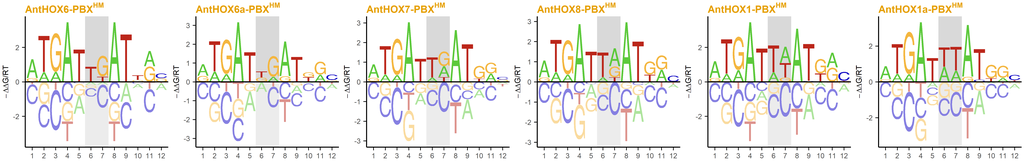

## Figure 2b: position 7 T-A-G projection

Base preferences at position 7 projected onto the T-A-G plane. T is at the top, G at the left and A at the right. Bars show the shared full-motif replicate discrepancy projected onto the three-HOX reference plane, as defined in Source data.

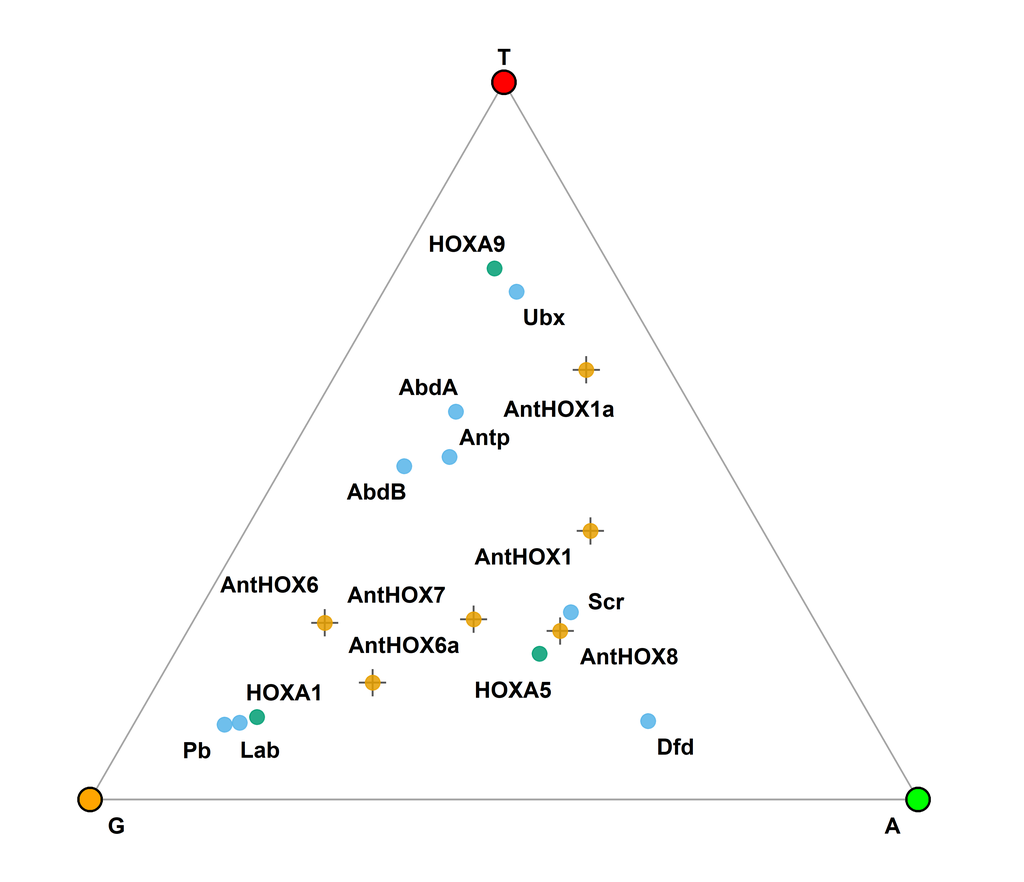

## Figure 2c: 12-mer specificity tree

Unrooted hierarchical clustering of specificity signatures for positions 1-12.

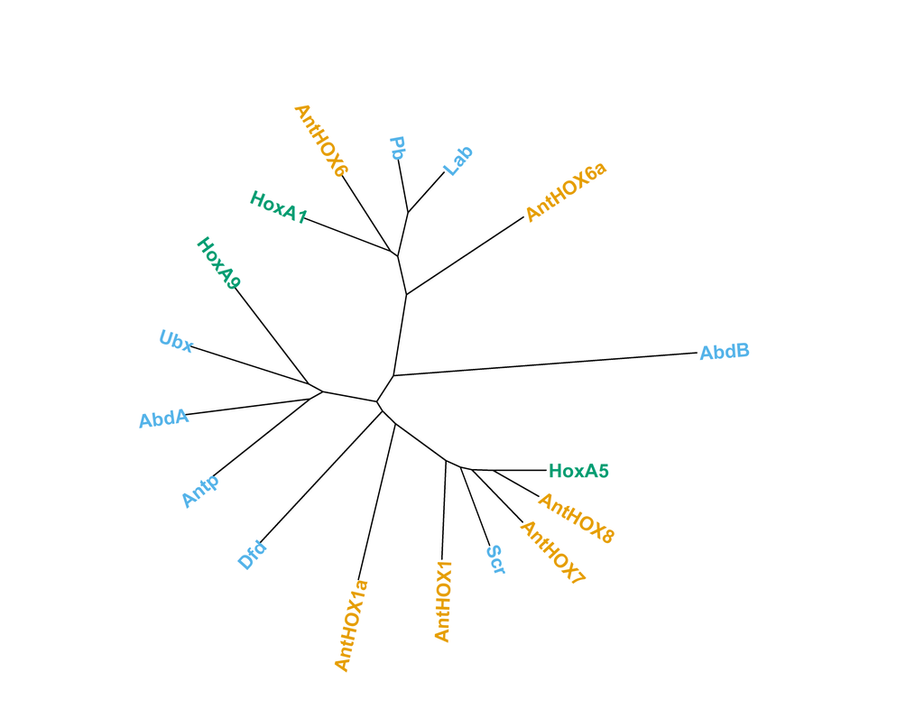

## Figure 2d: 8-mer specificity tree

Unrooted hierarchical clustering of specificity signatures for positions 2-9.

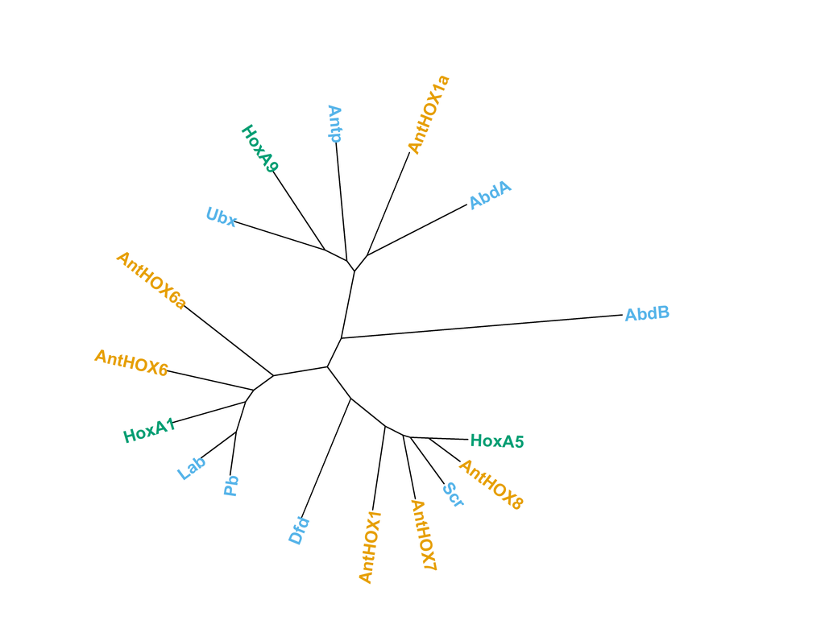

## Figure 2e: 4-mer specificity tree

Unrooted hierarchical clustering of specificity signatures for positions 6-9.

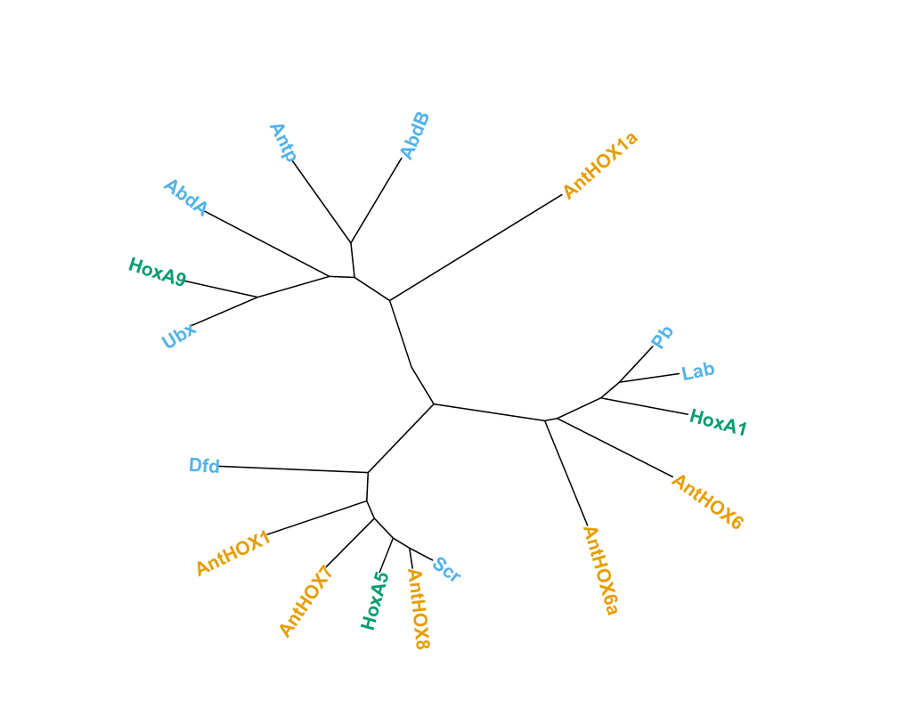

### Shared tree legend

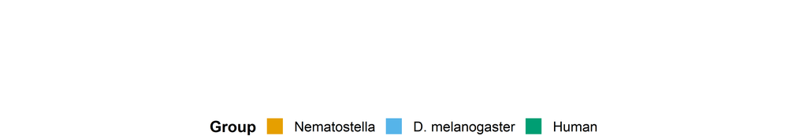

# Figure 3

Relative DNA-binding affinities are compared for 2,000 unique 12-mer sequences generated with random seed 42 from seven 8-mer cores and random flanking bases. For each sequence, affinities are summed over all binding windows in both the forward and reverse-complement orientations. Scoring uses four N bases at each end; an N contributes the least favorable coefficient at that position. Each window is scored relative to the optimal sequence for its model, and window affinities are summed without further rescaling. The same sequences and scoring procedure are used in Figures S7, S12 and S13. Dimer models span 12 positions and monomer models span eight positions. Colors identify the seven core sequences; lines show ordinary least-squares fits with an intercept.

## Figure 3a: AntHOX1a versus AntHOX6a

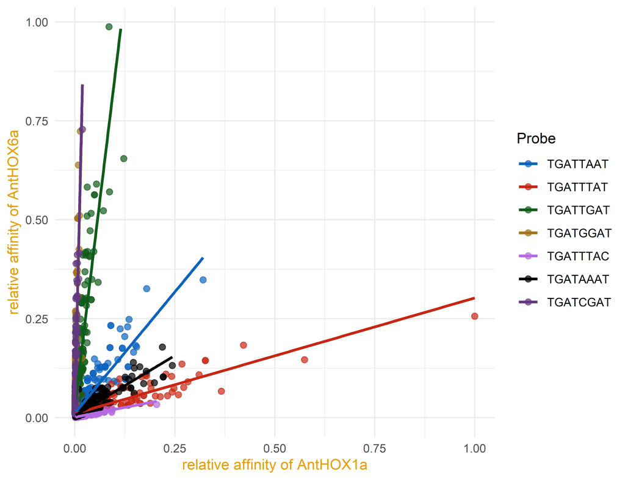

## Figure 3b: AntHOX1a versus AntHOX8

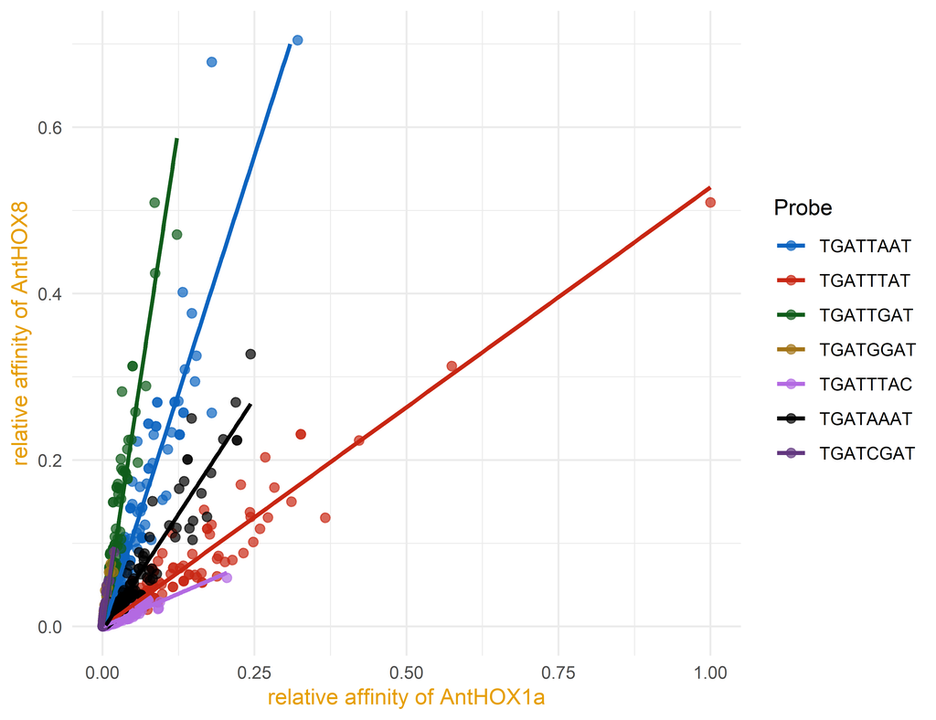

## Figure 3c: AntHOX6a versus AntHOX8

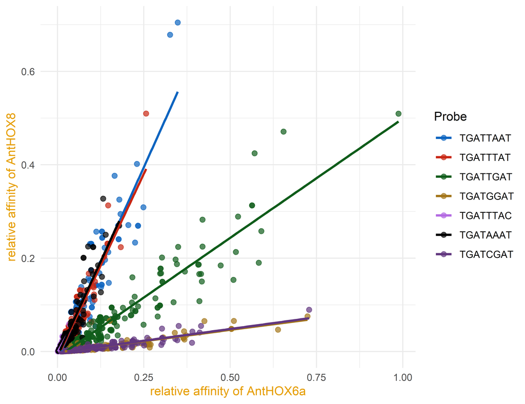

# Supplementary Figure 2

DNA-binding specificity signatures projected onto the plane defined by human HOXA1, HOXA5 and HOXA9. Panels a-c use positions 1-12, 2-9 and 6-9, respectively. Each selected position contributes its X, Y and Z tetrahedron coordinates. For the bars, each of four replicate differences retains all 36 coordinates and is projected onto the plane defined by the full 12-position HOXA1, HOXA5 and HOXA9 signatures. The mean of the four projected Euclidean lengths is the common bar half-width in panels a-c; total bar length is twice this mean. The same full-signature error calculation is used for the 12-mer, 8-mer and 4-mer panels.

## Figure S2a: 12-mer projection

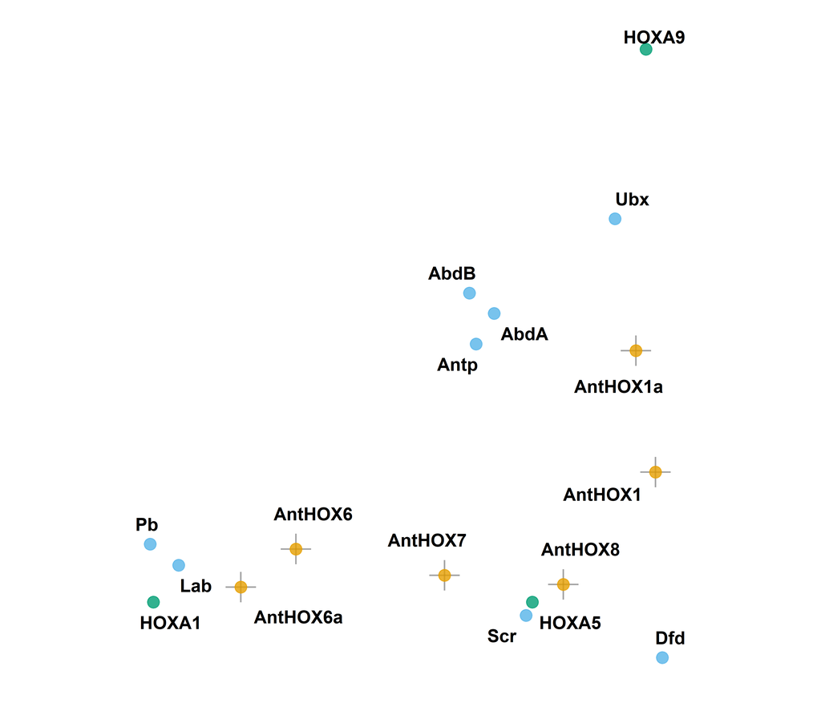

## Figure S2b: 8-mer projection

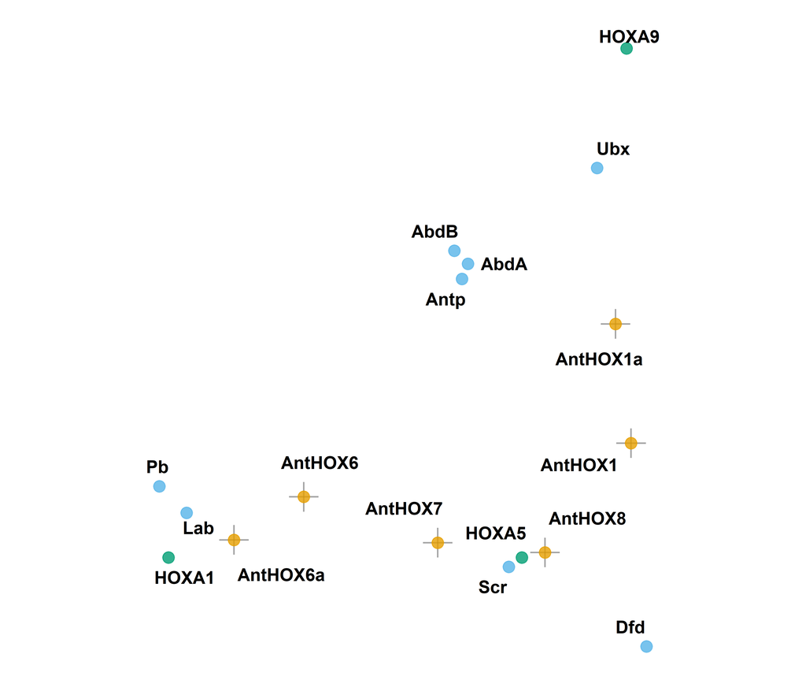

## Figure S2c: 4-mer projection

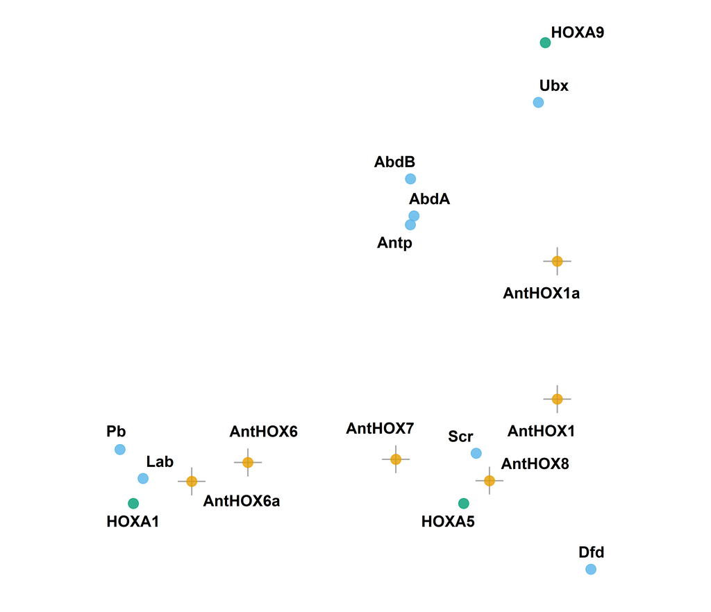

# Supplementary Figure 3

Cross-species 12-mer R-squared heatmap.

**Figure S3b**

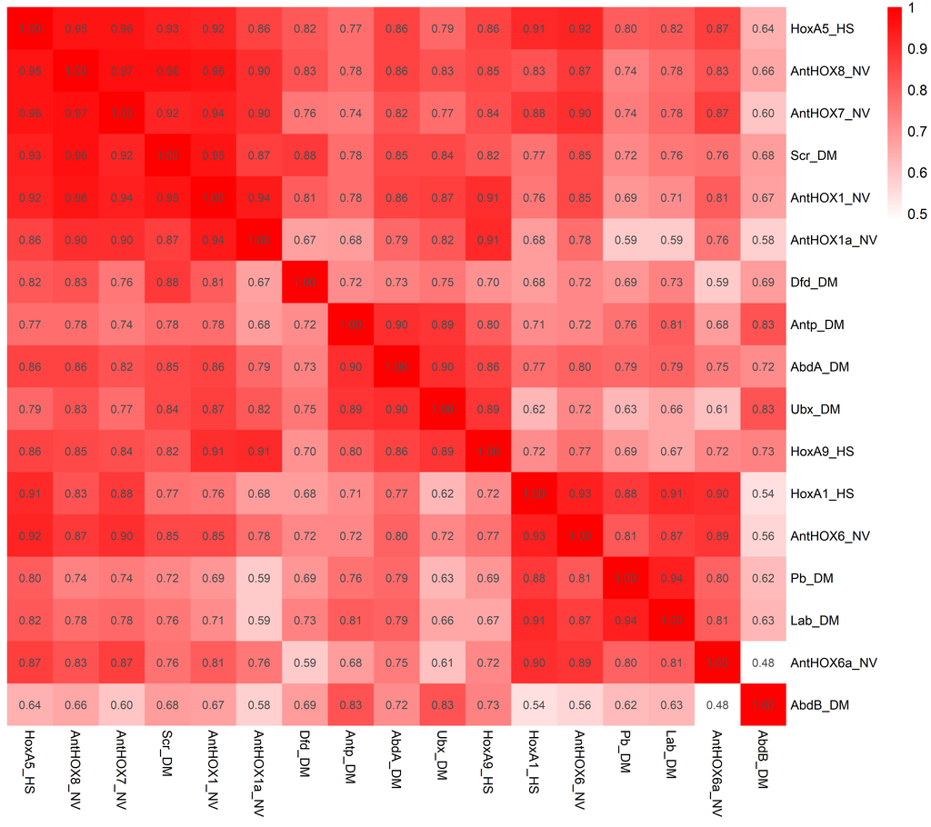

# Supplementary Figure 4

Cross-species HOX-PBX 8-mer R-squared heatmap.

**Figure S4b**

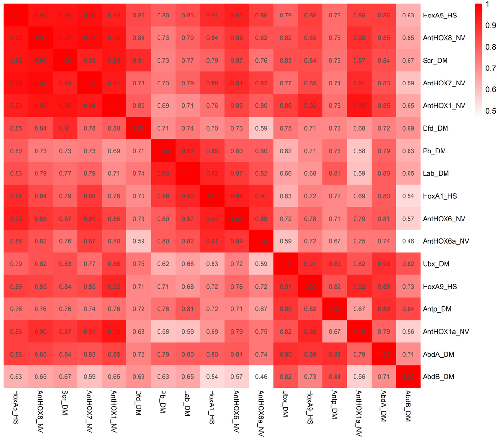

# Supplementary Figure 5

Cross-species HOX 4-mer R-squared heatmap.

**Figure S5b**

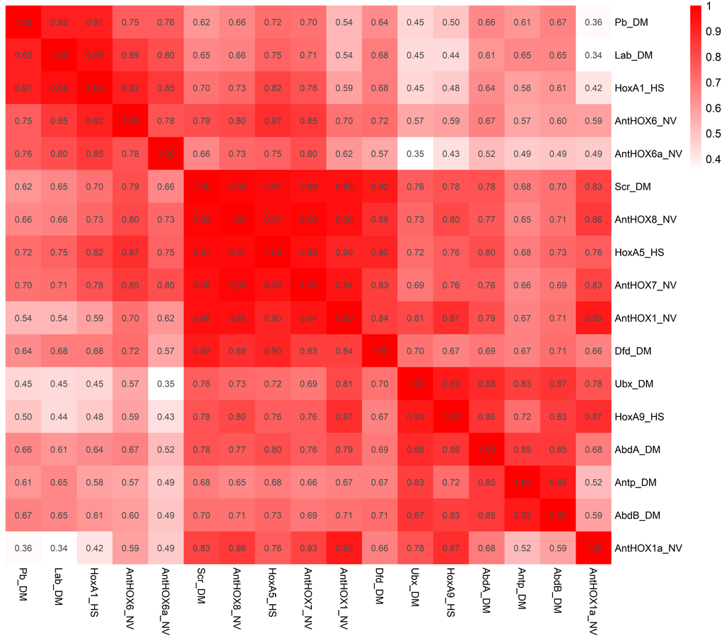

# Supplementary Figure 6

Human and Nematostella HOX-PBX 12-mer clustering.

**Figure S6b**

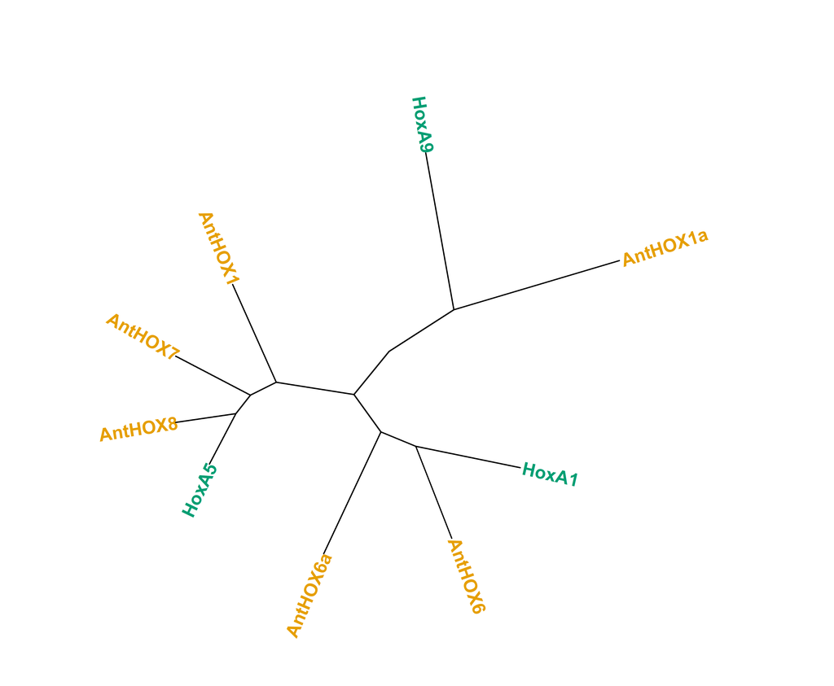

**Figure S6c**

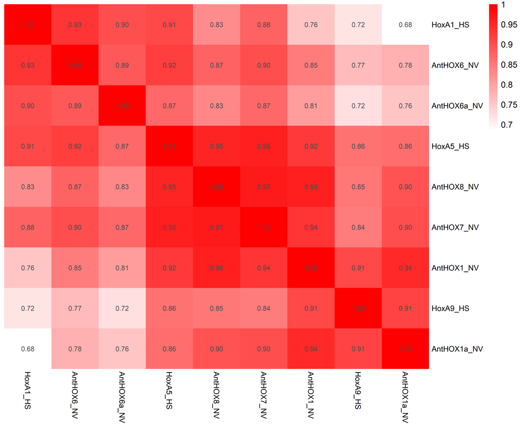

# Supplementary Figure 7

Pairwise synthetic-affinity comparisons among the three human anchors and the three directive-axis Nematostella HOX-PBX motifs.

**Figure S7a-l**

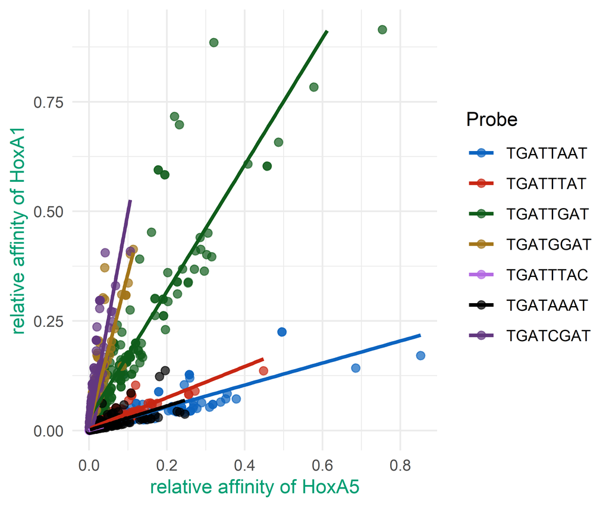

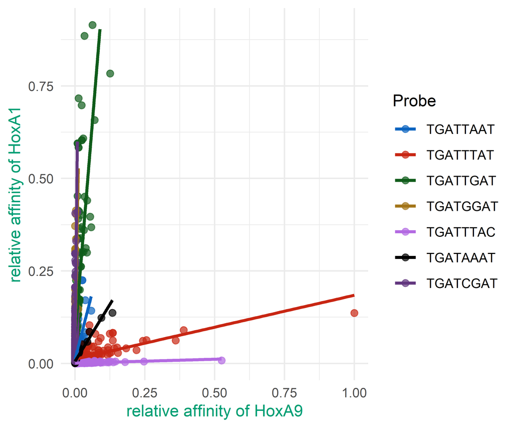

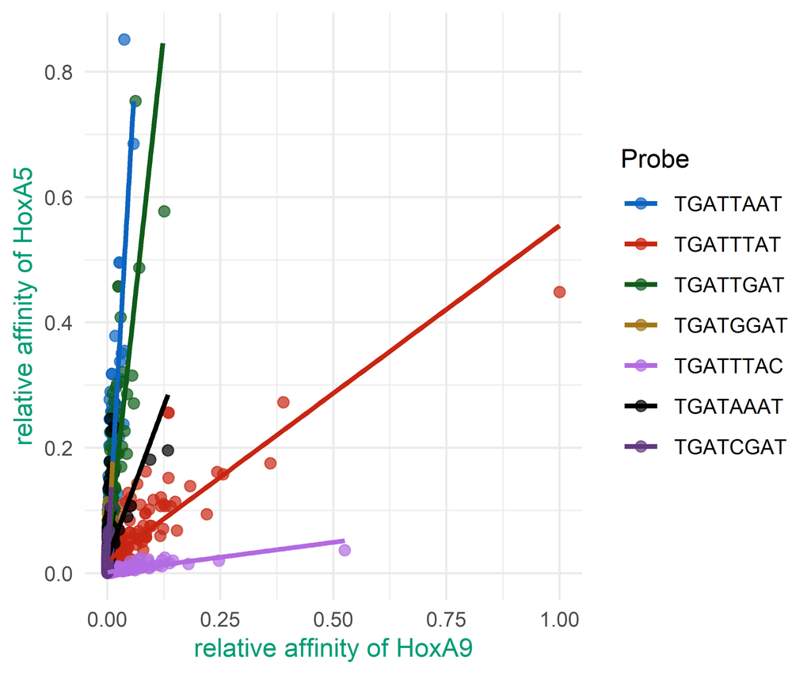

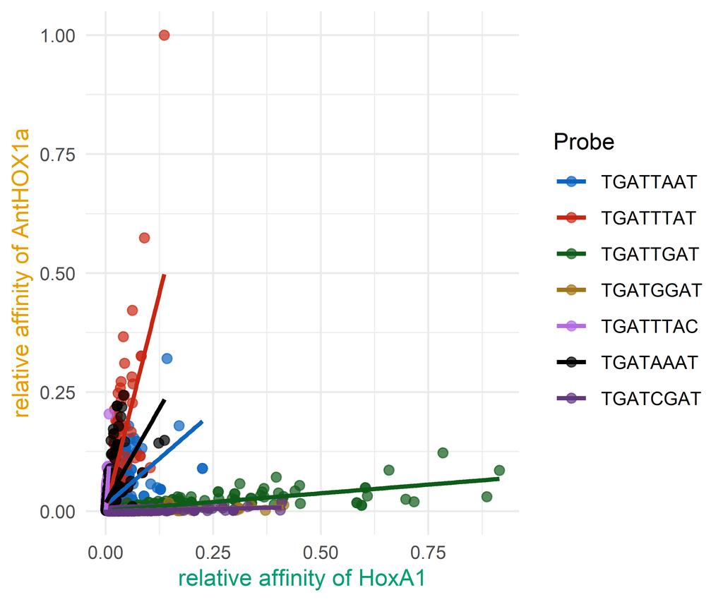

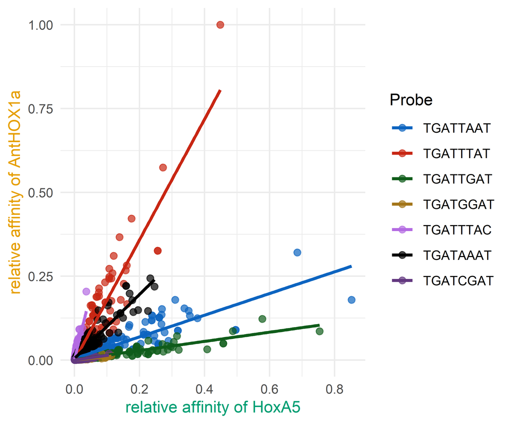

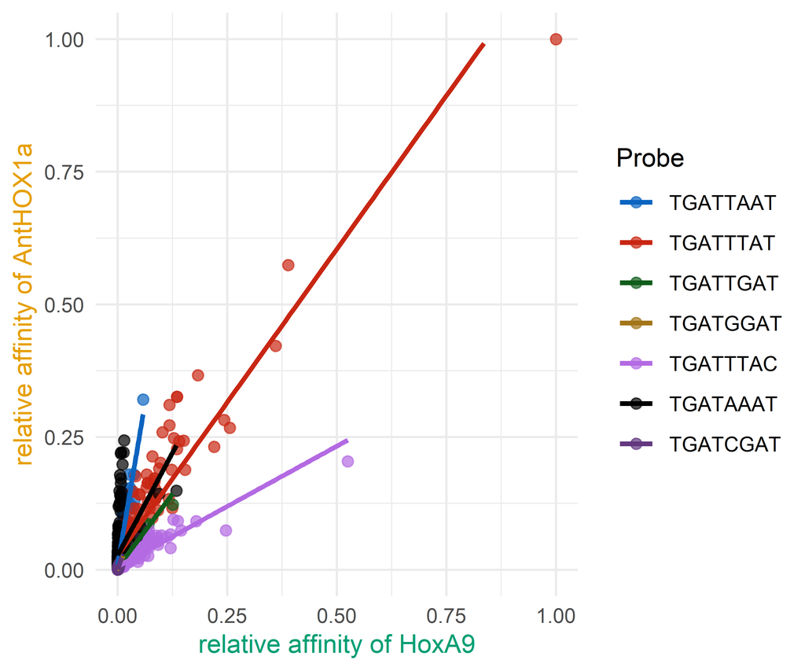

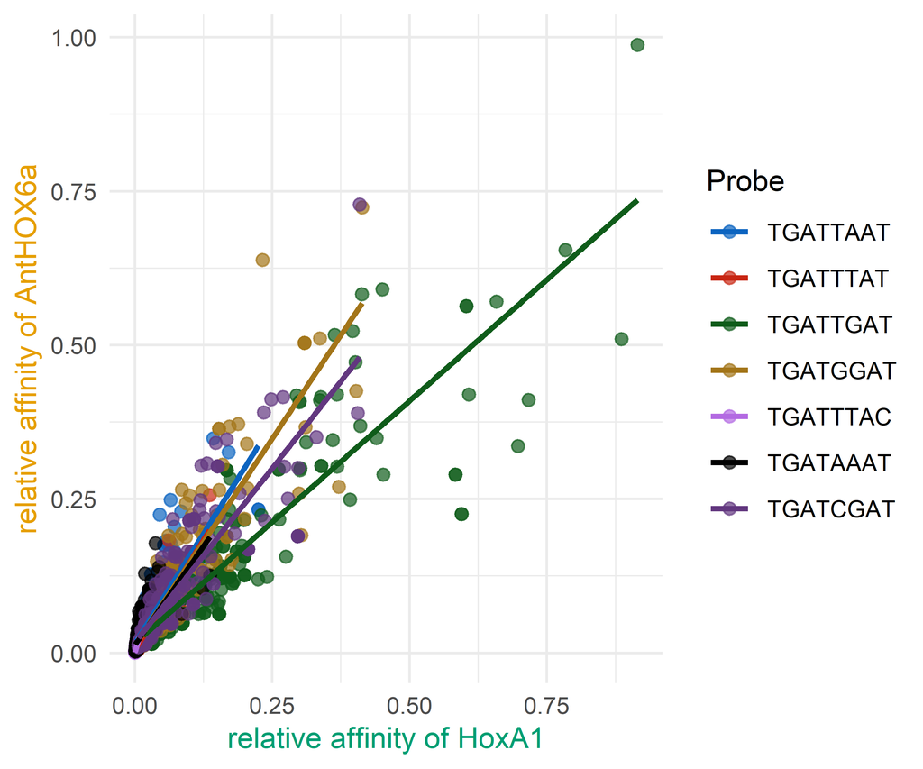

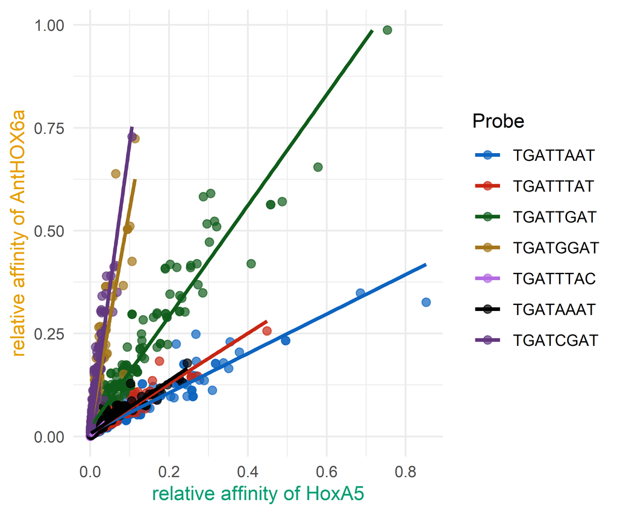

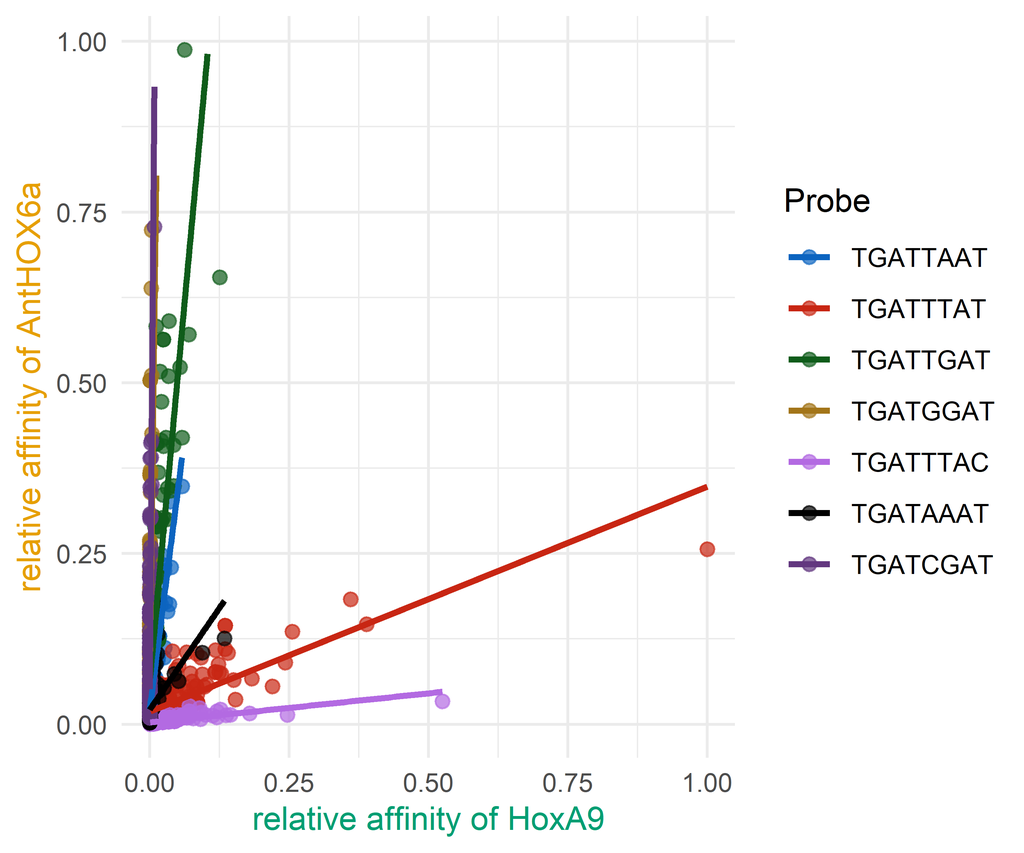

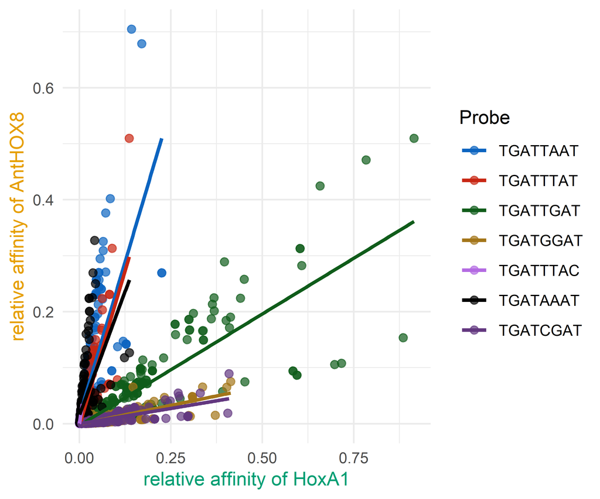

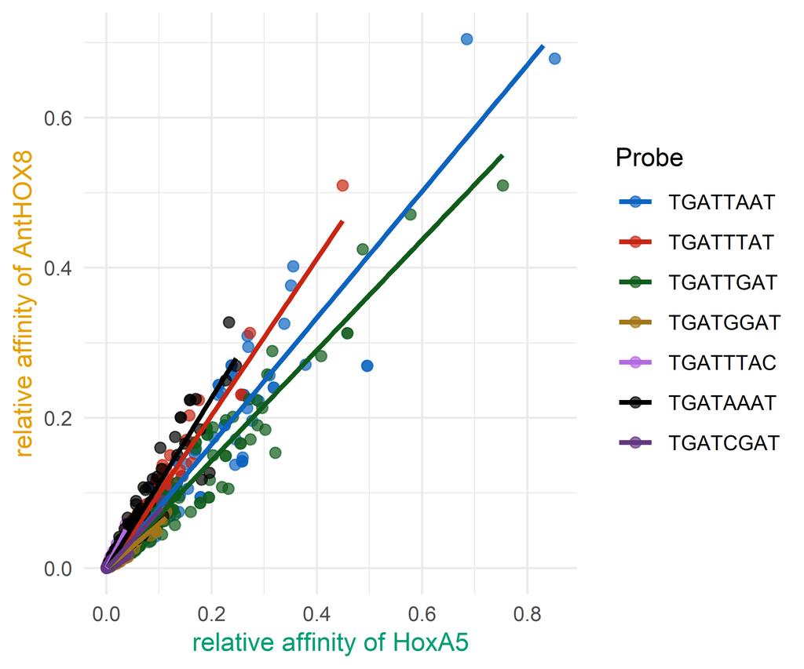

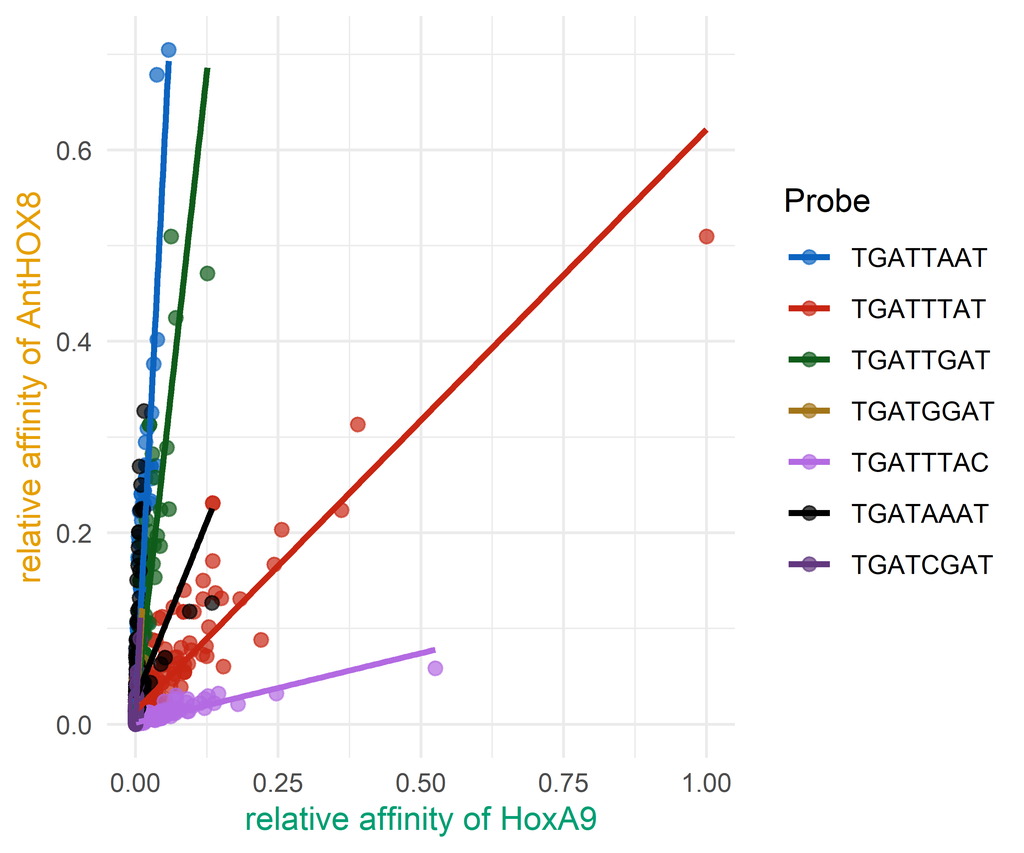

# Supplementary Figure 8

Representative Nematostella HOX-PBX 12-mer clustering.

**Figure S8b**

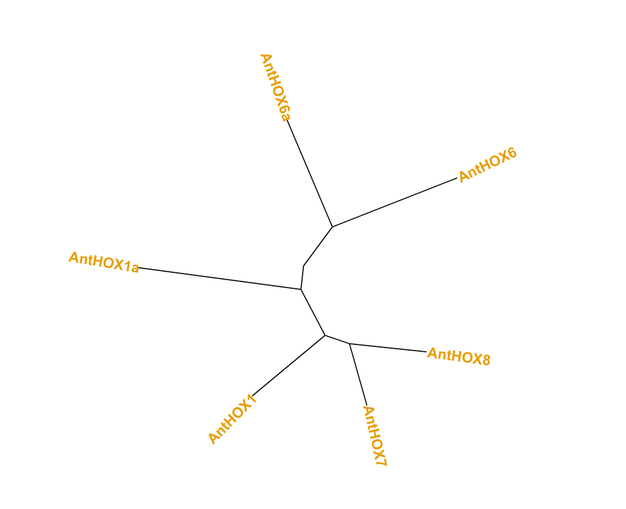

**Figure S8c**

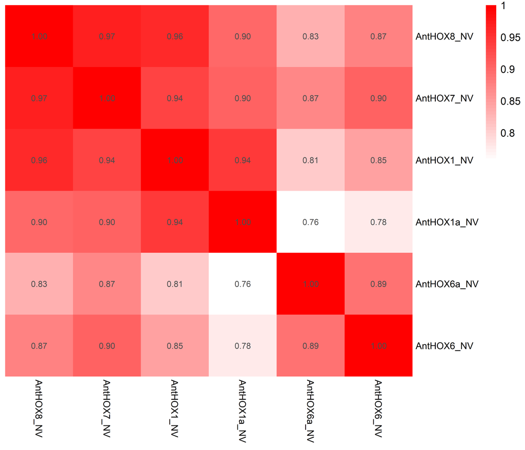